# Lab1

Collin Richter

10/19/2023

```r
library(ggplot2)
library(sf)
library(tidyverse)
library(stringr)
```

### 1. I will begin this assignment by using the using the Open Spaces and Mountain Parks of Boulder, Colorado Dataset. [here](https://drive.google.com/drive/folders/1YuX5oWjKS6vZx4zNyPwBKuiw9EJYNX5L?usp=sharing).

```r
boulder <- st_read("BoulderSocialMedia.shp")
```

This Here are the details of data:

| Variable | Description |
| --- | --- |
| DB | indicates whether the point is a social media location (Flickr or Panramio) or a point in the park |
| extent | extent that can be viewed at each point estimated through viewshed analysis |
| Climb_dist | distance to nearest climbing wall |
| TrailH_Dis | distance to hiking trails |
| NatMrk_Dis | distance to natural landmark |
| Trails_dis | distance to walking trails |
| Bike_dis | distance to biking trails |
| PrarDg_Dis | distance to prairie dog mounds |
| PT_Elev | Elevation |
| Hydro_dis | distance to lakes, rivers and creeks |
| Street_dis | distance to streets and parking lots |

boulder = st_transform(boulder, 26753)

### I am examining the correlation of the distance between social media locations and water to examine if people like to take pictures near water. This may indicate how picturesque the bodies of water are in the boulder area, which could lead to further examination of the health of the wetlands and water bodies and help determine where to allocate funds for potential restoration or beautification projects. Let’s look at the distance between all points and the bodies of water.

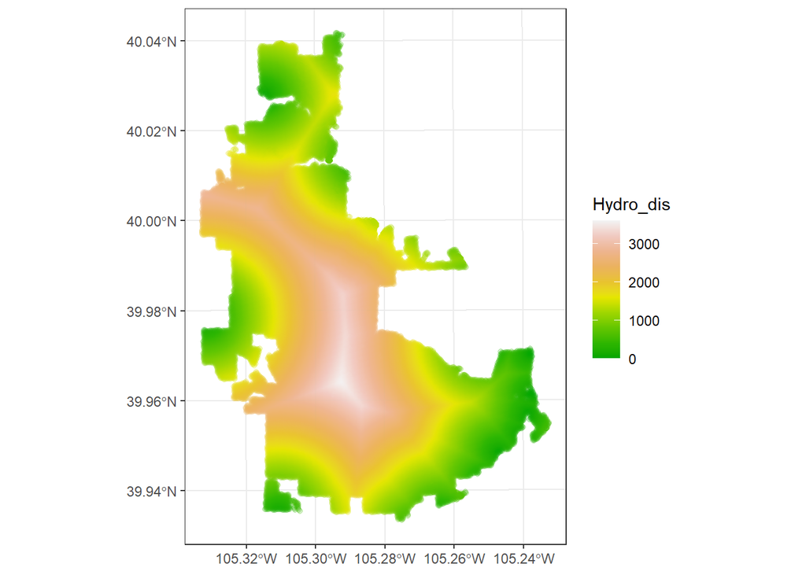

```r
boulder = st_transform(boulder, 26753)

ggplot() +
    geom_sf(data =boulder, aes(color= Hydro_dis),
    fill = NA, alpha = .2) + scale_colour_gradientn(colours = terrain.colors(10)) +
    theme_bw()
```

### Now, lets look at distance of points for each post on social media (Flickr and Pano) to water bodies

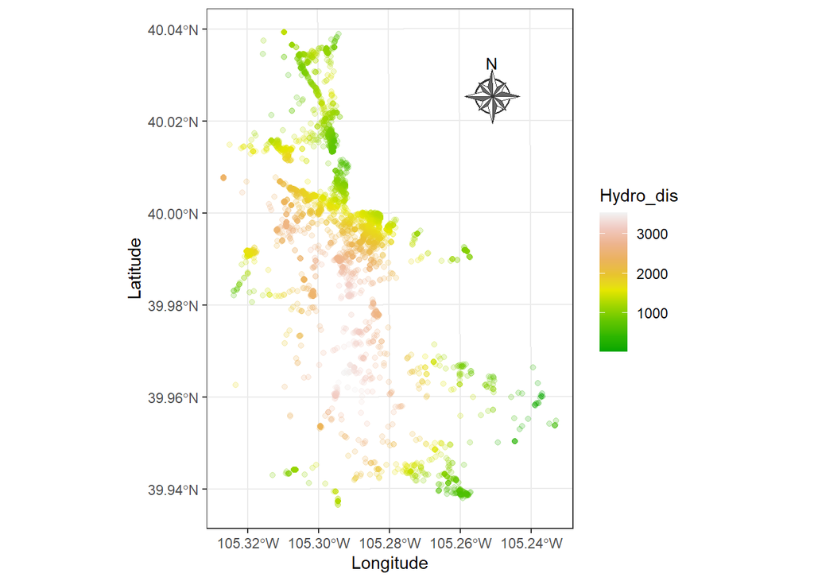

```r
library(ggspatial)
boulder$DB<-as.factor(boulder$DB)
boulder2<-boulder[boulder$DB != "OSMP_lands", drop = FALSE]

ggplot() +
    geom_sf(data =boulder2, aes(color= Hydro_dis),
    fill = NA, alpha = .2) + scale_colour_gradientn(colours = terrain.colors(10)) +labs(
    x = "Longitude",
    y = "Latitude"
  ) + theme_bw()+  ggspatial::annotation_north_arrow(
    location = "tr", which_north = "true",
    pad_x = unit(0.4, "in"), pad_y = unit(0.4, "in"),
    style = ggspatial::north_arrow_nautical(
      fill = c("grey40", "white"),
      line_col = "grey20",
      text_family = "ArcherPro Book"
    ))
```

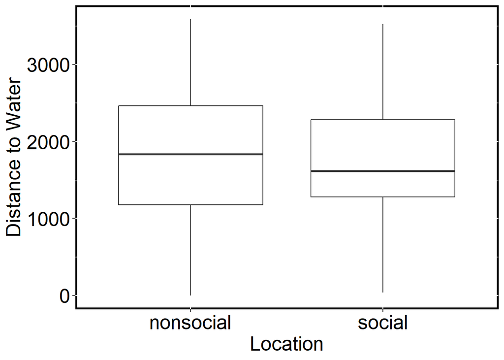

```r
boulderx<-subset(boulder, DB == "Flickr")
boulderx$loc_type<-"social"
bouldery<-subset(boulder, DB == "Pano")
bouldery$loc_type<-"social"
boulderz<-subset(boulder, DB == "OSMP_lands")
boulderz$loc_type<-"nonsocial"
boulder<-rbind(boulderx, bouldery, boulderz)


boulder %>%
  filter(loc_type ==  'social' | loc_type == 'nonsocial') %>%
  ggplot(aes(x=loc_type, y=Hydro_dis)) +
  geom_boxplot()+labs(
    x = "Location",
    y = "Distance to Water"
  ) + theme( panel.background = element_rect(fill = "white", color = 'black', size = 1.6, linetype = 'solid'),  text = element_text(size = 20),axis.text = element_text(colour = "black", size = 20))
```